# Projeto final

Bruno

31/01/2022

Este é o projeto final do curso de Data Analist, da Google. Na atividade o cenário proposto é que:

Você é um analista de dados júnior em uma empresa de compartilhamento de bicicletas de Chicago, nos Estados Unidos, que utiliza R para sua análises, onde a expectativa de crescimento, segundo o diretor de marketing, reside no aumento de membros com assinaturas anuais. Para isso o grupo bisca informações sobre as diferentes formas de uso entre os clientes casuais e os assinantes. Baseado nessas informações serão criadas estratégias de marketing para a conversão de membros casuais em membros anuais.

Com estas informações, três perguntas foram propostas:

1. Como os diferentes membros utilizam o serviço?
2. Por que membros casuais comprariam a assinatura anual?
3. Como a empresa usaria as mídias digitais para influenciar os membros casuais a se tornarem membros anuais?

Para isso foram disponibilizados os dados trimestrais da empresa.

### Preparação dos dados

Após ter acesso ao banco de dados é iniciada o processo de tratamento.

- Primeiramente são chamadas as bibliotecas necessárias para o desenvolvimento da análise.

```r
library(tidyverse)
library(lubridate)
library(ggplot2)
```

- Após isso os arquivos .csv são carregados no programa

```r
q2_2019 <- read_csv("Divvy_Trips_2019_Q2.csv")
q3_2019 <- read_csv("Divvy_Trips_2019_Q3.csv")
q4_2019 <- read_csv("Divvy_Trips_2019_Q4.csv")
q1_2020 <- read_csv("Divvy_Trips_2020_Q1.csv")
```

- Com os dados carregados no R, são verificados os nomes das colunas, para além da já visualizada no momento de carregamento. Para conhecer um pouco mais sobre a base de dados e verificar a possibilidade de mesclá-los em uma única base.

```r
colnames(q3_2019)
```

```
##  [1] "trip_id"           "start_time"        "end_time"
##  [4] "bikeid"            "tripduration"      "from_station_id"
##  [7] "from_station_name" "to_station_id"     "to_station_name"
## [10] "usertype"          "gender"            "birthyear"
```

```r
colnames(q4_2019)
```

```
##  [1] "trip_id"           "start_time"        "end_time"
##  [4] "bikeid"            "tripduration"      "from_station_id"
##  [7] "from_station_name" "to_station_id"     "to_station_name"
## [10] "usertype"          "gender"            "birthyear"
```

```r
colnames(q2_2019)
```

```
##  [1] "01 - Rental Details Rental ID"
##  [2] "01 - Rental Details Local Start Time"
##  [3] "01 - Rental Details Local End Time"
##  [4] "01 - Rental Details Bike ID"
##  [5] "01 - Rental Details Duration In Seconds Uncapped"
##  [6] "03 - Rental Start Station ID"
##  [7] "03 - Rental Start Station Name"
##  [8] "02 - Rental End Station ID"
##  [9] "02 - Rental End Station Name"
## [10] "User Type"
## [11] "Member Gender"
## [12] "05 - Member Details Member Birthday Year"
```

```r
colnames(q1_2020)
```

```
##  [1] "ride_id"            "rideable_type"      "started_at"
##  [4] "ended_at"           "start_station_name" "start_station_id"
##  [7] "end_station_name"   "end_station_id"     "start_lat"
## [10] "start_lng"          "end_lat"            "end_lng"
## [13] "member_casual"
```

Inicialmente já é possível perceber que as colunas não seguem uma nomeação padronizada precisando de ajustes, tanto nos nomes quanto no tipo de dados. Para isso será usada a base mais recente como base, esperando que no futuro, este seja o formato padrão adotado.

- Durante a renomeação foi preferido a manutenção dos termos em inglês visto a localização original da empresa e como dito anteriormente, para estar compapatível com os futuros bancos de dados.

```r
(q4_2019 <- rename(q4_2019
                   ,ride_id = trip_id
                   ,rideable_type = bikeid
                   ,started_at = start_time
                   ,ended_at = end_time
                   ,start_station_name = from_station_name
                   ,start_station_id = from_station_id
                   ,end_station_name = to_station_name
                   ,end_station_id = to_station_id
                   ,member_casual = usertype))
```

```
## # A tibble: 704,054 x 12
##     ride_id started_at          ended_at            rideable_type tripduration
##       <dbl> <dttm>              <dttm>                      <dbl>        <dbl>
##  1 25223640 2019-10-01 00:01:39 2019-10-01 00:17:20          2215          940
##  2 25223641 2019-10-01 00:02:16 2019-10-01 00:06:34          6328          258
##  3 25223642 2019-10-01 00:04:32 2019-10-01 00:18:43          3003          850
##  4 25223643 2019-10-01 00:04:32 2019-10-01 00:43:43          3275         2350
##  5 25223644 2019-10-01 00:04:34 2019-10-01 00:35:42          5294         1867
##  6 25223645 2019-10-01 00:04:38 2019-10-01 00:10:51          1891          373
##  7 25223646 2019-10-01 00:04:52 2019-10-01 00:22:45          1061         1072
##  8 25223647 2019-10-01 00:04:57 2019-10-01 00:29:16          1274         1458
##  9 25223648 2019-10-01 00:05:20 2019-10-01 00:29:18          6011         1437
## 10 25223649 2019-10-01 00:05:20 2019-10-01 02:23:46          2957         8306
## # ... with 704,044 more rows, and 7 more variables: start_station_id <dbl>,
## #   start_station_name <chr>, end_station_id <dbl>, end_station_name <chr>,
## #   member_casual <chr>, gender <chr>, birthyear <dbl>
```

```r
(q3_2019 <- rename(q3_2019
                   ,ride_id = trip_id
                   ,rideable_type = bikeid
                   ,started_at = start_time
                   ,ended_at = end_time
                   ,start_station_name = from_station_name
                   ,start_station_id = from_station_id
                   ,end_station_name = to_station_name
                   ,end_station_id = to_station_id
                   ,member_casual = usertype))
```

```
## # A tibble: 1,640,718 x 12
##     ride_id started_at          ended_at            rideable_type tripduration
##       <dbl> <dttm>              <dttm>                      <dbl>        <dbl>
##  1 23479388 2019-07-01 00:00:27 2019-07-01 00:20:41          3591         1214
##  2 23479389 2019-07-01 00:01:16 2019-07-01 00:18:44          5353         1048
##  3 23479390 2019-07-01 00:01:48 2019-07-01 00:27:42          6180         1554
##  4 23479391 2019-07-01 00:02:07 2019-07-01 00:27:10          5540         1503
##  5 23479392 2019-07-01 00:02:13 2019-07-01 00:22:26          6014         1213
##  6 23479393 2019-07-01 00:02:21 2019-07-01 00:07:31          4941          310
##  7 23479394 2019-07-01 00:02:24 2019-07-01 00:23:12          3770         1248
##  8 23479395 2019-07-01 00:02:26 2019-07-01 00:28:16          5442         1550
##  9 23479396 2019-07-01 00:02:34 2019-07-01 00:28:57          2957         1583
## 10 23479397 2019-07-01 00:02:45 2019-07-01 00:29:14          6091         1589
## # ... with 1,640,708 more rows, and 7 more variables: start_station_id <dbl>,
## #   start_station_name <chr>, end_station_id <dbl>, end_station_name <chr>,
## #   member_casual <chr>, gender <chr>, birthyear <dbl>
```

```r
(q2_2019 <- rename(q2_2019
                   ,ride_id = "01 - Rental Details Rental ID"
                   ,rideable_type = "01 - Rental Details Bike ID"
                   ,started_at = "01 - Rental Details Local Start Time"
                   ,ended_at = "01 - Rental Details Local End Time"
                   ,start_station_name = "03 - Rental Start Station Name"
                   ,start_station_id = "03 - Rental Start Station ID"
                   ,end_station_name = "02 - Rental End Station Name"
                   ,end_station_id = "02 - Rental End Station ID"
                   ,member_casual = "User Type"))
```

```
## # A tibble: 1,108,163 x 12
##     ride_id started_at          ended_at            rideable_type
##       <dbl> <dttm>              <dttm>                      <dbl>
##  1 22178529 2019-04-01 00:02:22 2019-04-01 00:09:48          6251
##  2 22178530 2019-04-01 00:03:02 2019-04-01 00:20:30          6226
##  3 22178531 2019-04-01 00:11:07 2019-04-01 00:15:19          5649
##  4 22178532 2019-04-01 00:13:01 2019-04-01 00:18:58          4151
##  5 22178533 2019-04-01 00:19:26 2019-04-01 00:36:13          3270
##  6 22178534 2019-04-01 00:19:39 2019-04-01 00:23:56          3123
##  7 22178535 2019-04-01 00:26:33 2019-04-01 00:35:41          6418
##  8 22178536 2019-04-01 00:29:48 2019-04-01 00:36:11          4513
##  9 22178537 2019-04-01 00:32:07 2019-04-01 01:07:44          3280
## 10 22178538 2019-04-01 00:32:19 2019-04-01 01:07:39          5534
## # ... with 1,108,153 more rows, and 8 more variables:
## #   `01 - Rental Details Duration In Seconds Uncapped` <dbl>,
## #   start_station_id <dbl>, start_station_name <chr>, end_station_id <dbl>,
## #   end_station_name <chr>, member_casual <chr>, `Member Gender` <chr>,
## #   `05 - Member Details Member Birthday Year` <dbl>
```

```r
## Mudando os tipo das variáveis, conforme os dados do q1_2021
q4_2019 <-  mutate(q4_2019, ride_id = as.character(ride_id)
                   ,rideable_type = as.character(rideable_type))
q3_2019 <-  mutate(q3_2019, ride_id = as.character(ride_id)
                   ,rideable_type = as.character(rideable_type))
q2_2019 <-  mutate(q2_2019, ride_id = as.character(ride_id)
                   ,rideable_type = as.character(rideable_type))
```

- Com as colunas renomeadas e os formatos de dados ajustados, é feita a junção das tabelas. Removendo as colunas não utilizadas.

```r
all_trips <- bind_rows(q2_2019, q3_2019, q4_2019, q1_2020)
all_trips <- all_trips %>%
  select(-c(start_lat, start_lng, end_lat, end_lng, birthyear, gender, "01 - Rental Details Duration In Seconds Uncapped", "05 - Member Details Member Birthday Year", "Member Gender", "tripduration"))
```

### Limpeza dos dados

- Inicialmente foi feita uma análise previa sobre as informações da base de dados, como número de colunas, linhas. Uma visualização das primeiras linhas de informação e alguns dados iniciais

```r
colnames(all_trips)
```

```
## [1] "ride_id"            "started_at"         "ended_at"
## [4] "rideable_type"      "start_station_id"   "start_station_name"
## [7] "end_station_id"     "end_station_name"   "member_casual"
```

```r
nrow(all_trips)
```

```
## [1] 3879822
```

```r
head(all_trips)
```

```
## # A tibble: 6 x 9
##   ride_id started_at          ended_at            rideable_type start_station_id
##   <chr>   <dttm>              <dttm>              <chr>                    <dbl>
## 1 221785~ 2019-04-01 00:02:22 2019-04-01 00:09:48 6251                        81
## 2 221785~ 2019-04-01 00:03:02 2019-04-01 00:20:30 6226                       317
## 3 221785~ 2019-04-01 00:11:07 2019-04-01 00:15:19 5649                       283
## 4 221785~ 2019-04-01 00:13:01 2019-04-01 00:18:58 4151                        26
## 5 221785~ 2019-04-01 00:19:26 2019-04-01 00:36:13 3270                       202
## 6 221785~ 2019-04-01 00:19:39 2019-04-01 00:23:56 3123                       420
## # ... with 4 more variables: start_station_name <chr>, end_station_id <dbl>,
## #   end_station_name <chr>, member_casual <chr>
```

```r
str(all_trips)
```

```
## tibble [3,879,822 x 9] (S3: tbl_df/tbl/data.frame)
##  $ ride_id           : chr [1:3879822] "22178529" "22178530" "22178531" "22178532" ...
##  $ started_at        : POSIXct[1:3879822], format: "2019-04-01 00:02:22" "2019-04-01 00:03:02" ...
##  $ ended_at          : POSIXct[1:3879822], format: "2019-04-01 00:09:48" "2019-04-01 00:20:30" ...
##  $ rideable_type     : chr [1:3879822] "6251" "6226" "5649" "4151" ...
##  $ start_station_id  : num [1:3879822] 81 317 283 26 202 420 503 260 211 211 ...
##  $ start_station_name: chr [1:3879822] "Daley Center Plaza" "Wood St & Taylor St" "LaSalle St & Jackson Blvd" "McClurg Ct & Illinois St" ...
##  $ end_station_id    : num [1:3879822] 56 59 174 133 129 426 500 499 211 211 ...
##  $ end_station_name  : chr [1:3879822] "Desplaines St & Kinzie St" "Wabash Ave & Roosevelt Rd" "Canal St & Madison St" "Kingsbury St & Kinzie St" ...
##  $ member_casual     : chr [1:3879822] "Subscriber" "Subscriber" "Subscriber" "Subscriber" ...
```

```r
summary(all_trips)
```

```
##    ride_id            started_at                     ended_at
##  Length:3879822     Min.   :2019-04-01 00:02:22   Min.   :2019-04-01 00:09:48
##  Class :character   1st Qu.:2019-06-23 07:49:09   1st Qu.:2019-06-23 08:20:27
##  Mode  :character   Median :2019-08-14 17:43:38   Median :2019-08-14 18:02:04
##                     Mean   :2019-08-26 00:49:59   Mean   :2019-08-26 01:14:37
##                     3rd Qu.:2019-10-12 12:10:21   3rd Qu.:2019-10-12 12:36:16
##                     Max.   :2020-03-31 23:51:34   Max.   :2020-05-19 20:10:34
##
##  rideable_type      start_station_id start_station_name end_station_id
##  Length:3879822     Min.   :  1.0    Length:3879822     Min.   :  1.0
##  Class :character   1st Qu.: 77.0    Class :character   1st Qu.: 77.0
##  Mode  :character   Median :174.0    Mode  :character   Median :174.0
##                     Mean   :202.9                       Mean   :203.8
##                     3rd Qu.:291.0                       3rd Qu.:291.0
##                     Max.   :675.0                       Max.   :675.0
##                                                         NA's   :1
##  end_station_name   member_casual
##  Length:3879822     Length:3879822
##  Class :character   Class :character
##  Mode  :character   Mode  :character
##
##
##
##
```

- Assim foi visto que, assim como os nomes das colunas o tipo de membro “casual” e “membro”, continham diferente nomenclaturas, então foi feita a padronização conforme os dados de 2020.

```r
all_trips <-  all_trips %>%
  mutate(member_casual = recode(member_casual
                                ,"Subscriber" = "member"
                                ,"Customer" = "casual"))
table(all_trips$member_casual)
```

```
##
##  casual  member
##  905954 2973868
```

- Além disso foi modificado o tipo de formato da data, bem como criado uma coluna para mês, dia, ano e dia da semana. Novamente preferiu-se a utilização das nomenclaturas em inglês.

```r
all_trips$date <- as.Date(all_trips$started_at) #The default format is yyyy-mm-dd
all_trips$month <- format(as.Date(all_trips$date), "%m")
all_trips$day <- format(as.Date(all_trips$date), "%d")
all_trips$year <- format(as.Date(all_trips$date), "%Y")
all_trips$day_of_week <- format(as.Date(all_trips$date), "%A")
```

- Conforme os ajustes avançam, foram criadas outras duas colunas, uma referente a mudança de estação entre a retirada da bicicleta e outra sobre o tempo de pedalada em minutos. Contudo o transporte das bicicletas para o HQ, para manutenção estava sendo mostrado nos dados, portanto foram removidas.

```r
all_trips$ride_length <- difftime(all_trips$ended_at,all_trips$started_at)
all_trips$ride_length <- as.numeric(as.character(all_trips$ride_length)) / 60
all_trips_v2 <- all_trips[!(all_trips$start_station_name == "HQ QR" | all_trips$ride_length<0),]
all_trips_v2 <- all_trips_v2 %>%
  mutate(change_statio = ifelse(start_station_id == end_station_id, "Change", "Keep"))
```

### Análise dos dados

- Primeiramente é pedido um teste para vizualizar as informações basicas sobre os dados, em especial o tempo de pedalada.

```r
summary(all_trips_v2$ride_length)
```

```
##      Min.   1st Qu.    Median      Mean   3rd Qu.      Max.
##      0.02      6.87     11.87     24.65     21.48 156450.40
```

Aqui é possível ver que a média (que corresponde a soma de todos os tempos dividido pelo número total de locações) apresenta um tempo de 24,65 minutos. O tempo mínimo correspondendo a uma desistência e o máximo a uma possível não devolução.

- Mais especificamente quanto a diferença entre os usuários casuais e os assinantes:

```r
aggregate(all_trips_v2$ride_length ~ all_trips_v2$member_casual, FUN = mean) # Média
```

```
##   all_trips_v2$member_casual all_trips_v2$ride_length
## 1                     casual                 59.21250
## 2                     member                 14.16777
```

```r
aggregate(all_trips_v2$ride_length ~ all_trips_v2$member_casual, FUN = median) # Mediana
```

```
##   all_trips_v2$member_casual all_trips_v2$ride_length
## 1                     casual                25.766667
## 2                     member                 9.816667
```

```r
aggregate(all_trips_v2$ride_length ~ all_trips_v2$member_casual, FUN = max) # Máximo
```

```
##   all_trips_v2$member_casual all_trips_v2$ride_length
## 1                     casual                 156450.4
## 2                     member                 150943.9
```

```r
aggregate(all_trips_v2$ride_length ~ all_trips_v2$member_casual, FUN = min) # Mínimo
```

```
##   all_trips_v2$member_casual all_trips_v2$ride_length
## 1                     casual               0.03333333
## 2                     member               0.01666667
```

Aqui é possível ver que os membros casuais tem um tempo de locação muito maior que os usuários anuais, possivelmente tendo como uso das bicicletas como passeio, já os membros utilizando mais como uma forma de deslocamento entre pontos. Mais sobre isso pode ver vistoa frente.

- Ao analisarmos o uso por dia da semana (pelo sistema onde foi feita a analise ser em português, os dias da semana estão em português, devendo ser ajustados conforme o idioma do sistema):

```r
all_trips_v2$day_of_week <- ordered(all_trips_v2$day_of_week, levels=c("domingo", "segunda-feira", "terça-feira",
                                                                       "quarta-feira", "quinta-feira",
                                                                       "sexta-feira", "sábado"))

aggregate(all_trips_v2$ride_length ~ all_trips_v2$member_casual + all_trips_v2$day_of_week, FUN = mean)
```

```
##    all_trips_v2$member_casual all_trips_v2$day_of_week all_trips_v2$ride_length
## 1                      casual                  domingo                 59.69009
## 2                      member                  domingo                 15.33291
## 3                      casual            segunda-feira                 56.20478
## 4                      member            segunda-feira                 14.04288
## 5                      casual              terça-feira                 59.93933
## 6                      member              terça-feira                 13.76905
## 7                      casual             quarta-feira                 61.97770
## 8                      member             quarta-feira                 13.73333
## 9                      casual             quinta-feira                 61.38308
## 10                     member             quinta-feira                 13.73213
## 11                     casual              sexta-feira                 62.89725
## 12                     member              sexta-feira                 13.74218
## 13                     casual                   sábado                 55.53190
## 14                     member                   sábado                 16.14890
```

É possível notar um uso progressivo durante a semana e atingindo um pico de tempo nas sextas-feiras, para os membros casuais e para os membros assinantes praticamente um patamar durante a semana com picos de tempo nos sábados e domingos. Mais facilmente visto no gráfico abaixo.

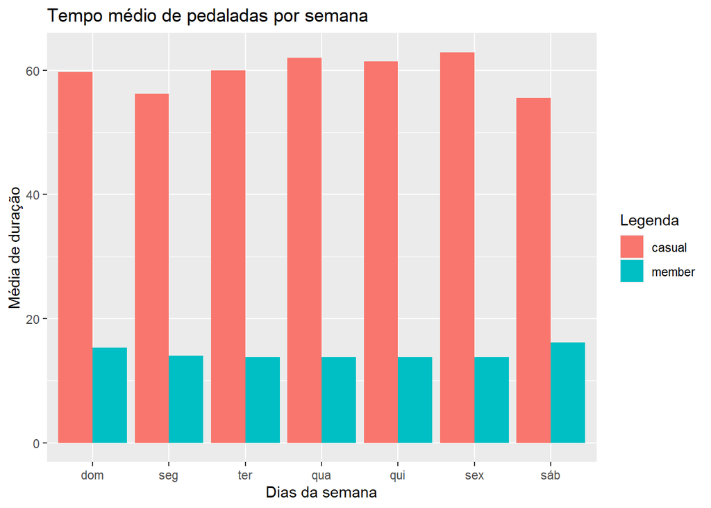

```r
all_trips_v2 %>%
  mutate(weekday = wday(started_at, label = TRUE)) %>%
  group_by(member_casual, weekday) %>%
  summarise(number_of_rides = n()
            ,average_duration = mean(ride_length)) %>%
  arrange(member_casual, weekday)  %>%
  ggplot(aes(x = weekday, y = average_duration, fill = member_casual)) +
  geom_col(position = "dodge") + labs(title = 'Tempo médio de pedaladas por semana', fill = "Legenda") +
  xlab("Dias da semana") + ylab('Média de duração')
```

- Já para a quantidade de locações:

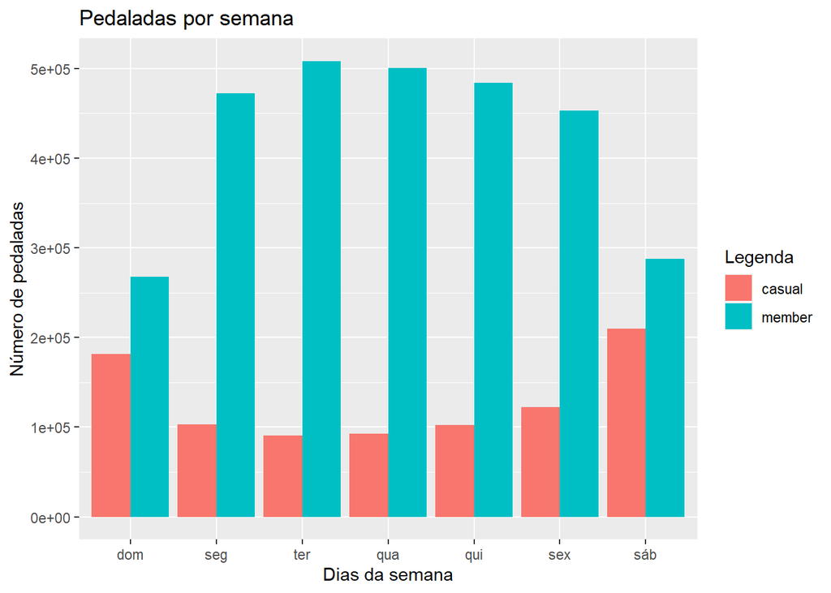

```r
all_trips_v2 %>%
  mutate(weekday = wday(started_at, label = TRUE)) %>%
  group_by(member_casual, weekday) %>%
  summarise(number_of_rides = n()
            ,average_duration = mean(ride_length)) %>%
  arrange(member_casual, weekday)  %>%
  ggplot(aes(x = weekday, y = number_of_rides, fill = member_casual)) +
  geom_col(position = "dodge") + labs(title = 'Pedaladas por semana',
                                      fill = "Legenda") +
  xlab("Dias da semana") + ylab('Número de pedaladas')
```

Fica claro que os membros assinantes fazem uma maior utilização do serviço durante os dias da semana e os membros casuais nos finais de semana.

- Repetindo as análises, agora com relação aos meses.

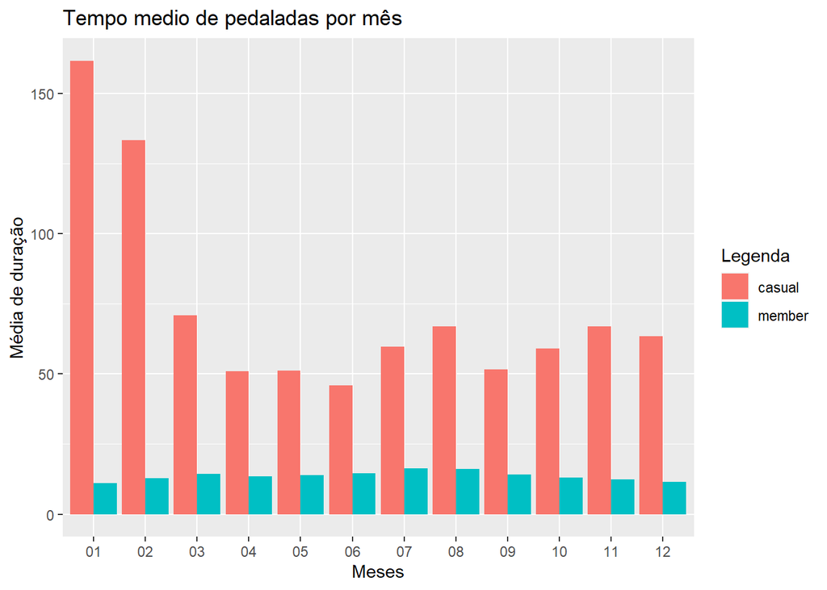

```r
all_trips_v2 %>% ## Duração por mes
  group_by(member_casual, month) %>%
  summarise(number_of_rides = n()
            ,average_duration = mean(ride_length)) %>%
  arrange(member_casual, month)  %>%
  ggplot(aes(x = month, y = average_duration, fill = member_casual)) +
  geom_col(position = "dodge") + labs(title = 'Tempo medio de pedaladas por mês', fill = "Legenda") +
  xlab("Meses") + ylab('Média de duração')
```

É possível notar um que durante os primeiros meses do ano, janeiro e fevereiro, possuem picos de tempo médio de pedalada para os membros casuais, possivelmente devido a tentativas de mudanças de comportamento causadas pela passagem de ano.

- Já com relação a quantidade de corridas:

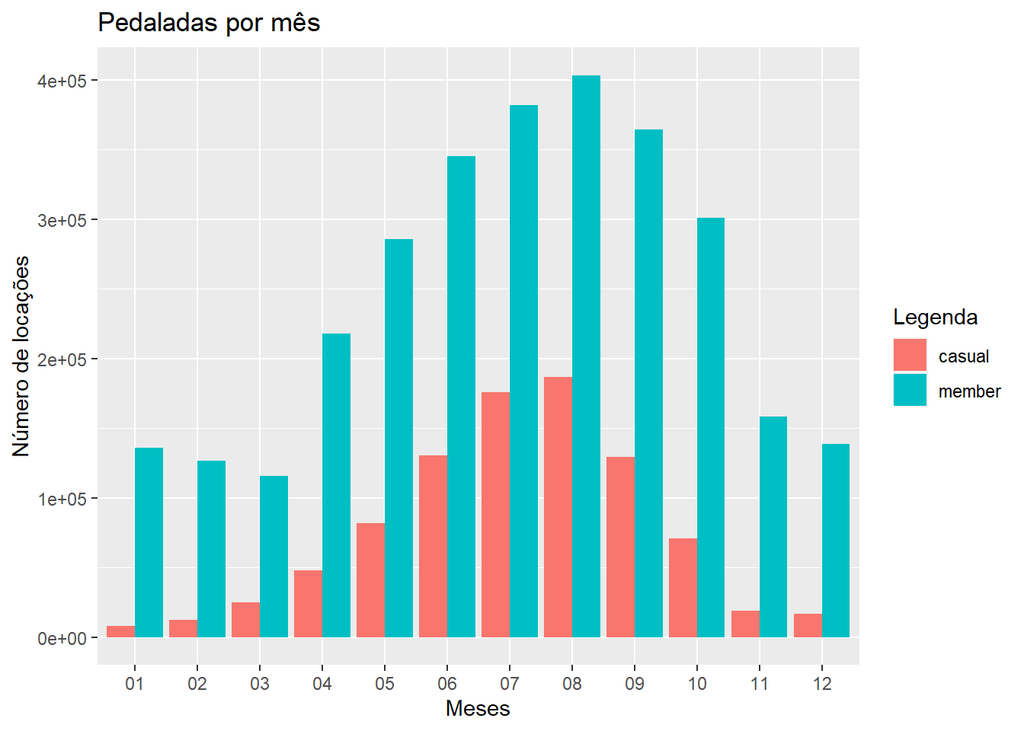

```r
all_trips_v2 %>% ## Quantidade por mes
  group_by(member_casual, month) %>%
  summarise(number_of_rides = n()
            ,average_duration = mean(ride_length)) %>%
  arrange(member_casual, month)  %>%
  ggplot(aes(x = month, y = number_of_rides, fill = member_casual)) +
  geom_col(position = "dodge") + labs(title = 'Pedaladas por mês',
                                      fill = "Legenda") +
  xlab("Meses") + ylab('Número de locações')
```

É notável um aumento durante os meses mais quentes do ano, visto que Chicago localiza-se no hemisfério norte, vai de junho a setembro e o inverno de dezembro a março.

- Como último ponto, sobre a mudança de estações de retirada e devolução:

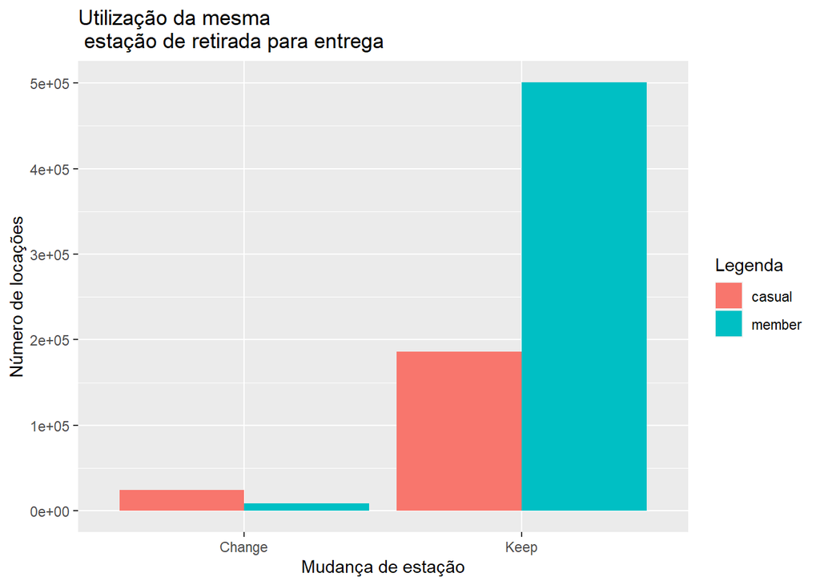

```r
all_trips_v2 %>% ## Grafico por mudança de estação
  mutate(weekday = wday(started_at, label = TRUE)) %>%
  group_by(member_casual,weekday,  change_statio) %>%
  summarise(number_of_rides = n()
            ,average_duration = mean(ride_length)) %>%
  arrange(member_casual,  change_statio)  %>%
  ggplot(aes(x = change_statio, y = number_of_rides, fill = member_casual )) +
  geom_col(position = "dodge") + labs(title = 'Utilização da mesma \n estação de retirada para entrega', fill = "Legenda") +
  xlab("Mudança de estação") + ylab('Número de locações')
```

## Conclusôes

Para o aumento de assinantes anuais, é possível explorar três características o aumento do tempo das pedaladas no início do ano, uma maior utilização nos fins de semana e nos meses mais quentes do ano.

A maior diferença entre a forma de utilização dos serviços estão em: tempos mais longos para casuais e uma maior utilização nos finais de semana. Além de uma procura muito baixa nos meses de inverno.

Uma possível forma de explorar as mídias sociais para converter casuais em assinantes seriam mensagens/ anúncios sobre estilos de vida mais saudáveis e explorar a paisagem da cidade.

Um possível motivo de conversão seria uma diminuição do valor pago visto que a utilização deles é mais longa, então um plano que contemple um abono pode levar mais usuário a se tornarem assinantes.

Mas para melhor direcionamentos, outros dados deveriam ser inclusos nos bancos de dados da empresa. É necessário fazer uma avaliação sobre a finalidade de uso, transporte ou passeio, para isso precisando de mais informações sobre a localização da bicicleta. Para um maior alcance de mídias socias, saber se uma campanha deve ser focada em um certo gênero ou faixa etária faria diferença.

Para uma melhor visualização recomenda-se o link para o [Tableau Public](https://public.tableau.com/shared/723CZDMNS?:display_count=n&:origin=viz_share_link)